# qPCR analysis of ATM targeting CRISPRi screen for GBM

Catherine Taylor (internship at MIlner Theraputics at Cambridge University - Supervisor - Sukjun Lee

2025-09-07

#### Glioblastoma (GBM) is the most common and aggressive primary brain tumour in adults, accounting for ~50% of all malignant gliomas (Ostrom et al., 2021). Despite maximal surgical resection followed by radiotherapy and temozolomide chemotherapy (the Stupp protocol), prognosis remains poor, with a median survival of only 14–16 months and a 5-year survival rate of <10% (Stupp et al., 2005; Weller et al., 2017). Treatment failure is driven by Glioblastoma stem-like cancer cells (GSCs), intratumoural heterogeneity, and particularly radio-resistance, which is mediated by efficient DNA damage repair pathways (Carruthers et al., 2018). Furthermore, this drives recurrence and mortality. Strategies to overcome this resistance include targeting the DNA-damage response (DDR) to sensitise tumour cells to radiation. The kinase ATM (ataxia-telangiectasia mutated) is a master regulator of double-strand break signalling and repair, and its inhibition has been shown to enhance radiation sensitivity in preclinical GBM models (Rainey et al., 2020; Durant & Fink, 2021).

#### Our platform builds on the 3D clonogenic assay originally developed on Alvetex scaffolds by Anthony J. Chalmers (University of Glasgow) and Natividad Gómez-Román (University of Strathclyde) (Chalmers et al., 2017; Gómez-Román et al., 2020), which the Milner Therapeutics Institute has collaborated with there specialised CRISPR technology team for screening, including improved automated colony quantification with support from Anke Husmann (bioinformatics). This collaboration has also enabled the sharing and utilisation of the G7 cancer cell line, which is a glioblastoma tissue sample initially isolated and characterised by Colin Watts in Cambridge. Jun, my supervisor, has engineered this cell line using the CRISPRi screening tool - G7-Zim3 CRISPRi GBM line (dCas9-ZIM3-KRAB). This also includes an attached repressor domain (ZIM3-KRAB fusion).

#### The project adapts and scales a reverse-transfection workflow from 48- to 96-well format, enabling automated handling on a liquid handler and transfer to Alvetex plates for 3D clonogenic readouts under 0 Gy and 3 Gy conditions. As part of assay development and target validation, we quantify on-target transcriptional repression of ATM following CRISPRi with two independent sgRNAs (ATM1 and ATM2) relative to a non-targeting control (NT-sgRNA). This qPCR analysis covers two designs: (i) pooled cells harvested from first 96 well plate reverse transfection using full automation, and (ii) a concentration series comparing 0.45 µM vs 0.045 µM sgRNA input across replicate reverse transfections manually.

#### GBM cells were reverse-transfected in Matrigel-coated 96-well plates using Lipofectamine™ RNAiMAX with ATM1, ATM2, or NT sgRNAs. Cells were seeded at 8,000 per well and incubated for 72 h before harvest. RNA was extracted with TRIzol and the Micro Kit, quantified by NanoDrop, and reverse-transcribed with the Transcriptor First Strand cDNA Synthesis Kit using random hexamers. qPCR was performed on QuantStudio instruments with PowerUp™ SYBR™ Green, using ACTB as the internal control. Relative ATM expression was determined by the ΔΔCt method, reporting fold-change normalised to NT-sgRNA. These data provide molecular validation of ATM repression under both standard and reduced-dose sgRNA conditions, supporting the incorporation of CRISPR-based screening into the ClonoScreen3D platform for the scalable discovery of radiosensitisers in GBM.

### qPCR results from (i)- NOTE: This data is from the same sample but I completed 2 technical replicates of the qPCR.

```r
need <- c(
  "readr","readxl","dplyr","tidyr","stringr","purrr","janitor","ggplot2","forcats"
)
to_install <- setdiff(need, rownames(installed.packages()))
if (length(to_install)) install.packages(to_install, quiet = TRUE)
invisible(lapply(need, library, character.only = TRUE))
data <- read_csv("13.Aug.pooled.csv")
```

```
## ──────────────────────────────────────────────────────── Delimiter: "," chr
## (13): ...1, 1, 2, 3, 4, 5, 6, 7, 8, 9, 10, 11, 12 lgl (1): ...14
```

```r
head(data)
```

```
## # A tibble: 6 × 14
##   ...1  `1`    `2`   `3`   `4`   `5`   `6`   `7`   `8`   `9`   `10`  `11`  `12`
##   <chr> <chr>  <chr> <chr> <chr> <chr> <chr> <chr> <chr> <chr> <chr> <chr> <chr>
## 1 A     Undet… Unde… Unde… Unde… Unde… Unde… Unde… Unde… Unde… Unde… Unde… Unde…
## 2 B     Undet… 17.6… 17.2… 17.1… 17.7… 17.6… 17.7… 19.1… 19.5… 19.5… Unde… Unde…
## 3 C     Undet… 35.4… Unde… 35.1… 33.2… 34.2… 33.0… 29.8… 30.1… 30.2… Unde… Unde…
## 4 D     Undet… Unde… Unde… Unde… Unde… Unde… Unde… Unde… Unde… Unde… Unde… Unde…
## 5 E     Undet… Unde… Unde… Unde… Unde… Unde… Unde… Unde… Unde… Unde… Unde… Unde…
## 6 F     Undet… Unde… Unde… Unde… Unde… Unde… Unde… Unde… Unde… Unde… Unde… Unde…
## # ℹ 1 more variable: ...14 <lgl>
```

```r
data <- read_csv("15.Aug.96w.csv")
```

```
## ──────────────────────────────────────────────────────── Delimiter: "," chr
## (13): ...1, 1, 2, 3, 4, 5, 6, 7, 8, 9, 10, 11, 12
```

```r
head(data)
```

```
## # A tibble: 6 × 13
##   ...1  `1`    `2`   `3`   `4`   `5`   `6`   `7`   `8`   `9`   `10`  `11`  `12`
##   <chr> <chr>  <chr> <chr> <chr> <chr> <chr> <chr> <chr> <chr> <chr> <chr> <chr>
## 1 A     Undet… Unde… Unde… Unde… Unde… Unde… Unde… Unde… Unde… Unde… Unde… Unde…
## 2 B     Undet… 17.7… 18.0… 17.9… 18.2… 18.1… 18.1… 20.1… 19.8… 20.0… Unde… Unde…
## 3 C     Undet… Unde… Unde… 35.7… 34.1… 34.9… 34.1… 31.3… 31.3… 31.0… Unde… Unde…
## 4 D     Undet… Unde… Unde… Unde… Unde… Unde… Unde… Unde… Unde… Unde… Unde… Unde…
## 5 E     Undet… Unde… Unde… Unde… Unde… Unde… Unde… Unde… Unde… Unde… Unde… Unde…
## 6 F     Undet… Unde… Unde… Unde… Unde… Unde… Unde… Unde… Unde… Unde… Unde… Unde…
```

```r
## 1) Paths + basic labels
CSV_REP1 <- "13.Aug.pooled.csv"   # first technical replicate
CSV_REP2 <- "15.Aug.96w.csv"      # second technical replicate

CONTROL_LABEL <- "NtsgRNA"        # your calibrator / control
TARGET_GENE   <- "ATM"            # target gene
REF_GENE      <- "ACTB"           # housekeeping gene

# How to handle "Undetermined": NA = drop from means; use 40 if your SOP wants max cycles
UND_CT <- NA_real_                # or 40

## 2) Plate mapping encoded in code
# Columns 2–4  -> "ATM 2 sgRNA"
# Columns 5–7  -> "ATM 1 sgRNA"
# Columns 8–10 -> "NtsgRNA"
sample_from_col <- function(colN) case_when(
  colN %in% 2:4  ~ "ATM 2 sgRNA",
  colN %in% 5:7  ~ "ATM 1 sgRNA",
  colN %in% 8:10 ~ "NtsgRNA",
  TRUE ~ NA_character_
)

# Rows: B = ACTB (ref), C = ATM (target).
gene_from_row <- function(rowL) case_when(
  toupper(rowL) == "B" ~ REF_GENE,
  toupper(rowL) == "C" ~ TARGET_GENE,
  TRUE ~ NA_character_
)

## 3) Read + tidy ONE csv
parse_raw_csv <- function(path, run_label) {
  # Read everything as character so "Undetermined" is preserved
  df <- read_csv(path, col_types = cols(.default = col_character()), show_col_types = FALSE)

  # Rename the first column to "rowL" (A..H). Keep only columns named 1..12.
  names(df)[1] <- "rowL"
  df <- df %>% select(rowL, matches("^\\d+$"))

  # Make long format: one row per well
  df_long <- df %>%
    pivot_longer(-rowL, names_to = "col", values_to = "ct_raw") %>%
    mutate(
      rowL    = toupper(str_trim(rowL)),       # "A".."H"
      col_num = as.integer(col),               # "1".."12" -> 1..12
      well    = sprintf("%s%02d", rowL, col_num),
      # Convert Ct: numeric if possible; if "Undetermined", set to UND_CT (NA or 40)
      ct      = suppressWarnings(as.numeric(ct_raw)),
      ct      = if_else(is.na(ct) & !is.na(ct_raw) &
                          str_detect(ct_raw, regex("^undetermined$", TRUE)),
                        UND_CT, ct),
      # Map to your sample/groups and genes
      sample  = sample_from_col(col_num),
      gene    = gene_from_row(rowL),
      run     = run_label
    ) %>%
    # Keep only wells that belong to our mapping and that have numeric Ct
    filter(!is.na(sample), !is.na(gene), !is.na(ct)) %>%
    select(run, well, rowL, col_num, sample, gene, ct)

  df_long
}

## 4) ΔΔCt for ONE replicate
compute_ddct <- function(per_well_df) {
  # Mean Ct per run × sample × gene
  gene_means <- per_well_df %>%
    group_by(run, sample, gene) %>%
    summarise(mean_ct = mean(ct, na.rm = TRUE), .groups = "drop")

  # ΔCt = Ct_target - Ct_ref for each sample (within each run)
  wide <- gene_means %>%
    filter(gene %in% c(TARGET_GENE, REF_GENE)) %>%
    pivot_wider(names_from = gene, values_from = mean_ct)

  # Safety check: both columns present
  stopifnot(all(c(TARGET_GENE, REF_GENE) %in% names(wide)))

  dCt <- wide %>%
    mutate(delta_ct = .data[[TARGET_GENE]] - .data[[REF_GENE]]) %>%
    select(run, sample, delta_ct)

  # Calibrator ΔCt (control mean within each run)
  cal <- dCt %>%
    filter(sample == CONTROL_LABEL) %>%
    group_by(run) %>%
    summarise(cal_delta_ct = mean(delta_ct, na.rm = TRUE), .groups = "drop")

  # ΔΔCt and fold change
  final <- dCt %>%
    left_join(cal, by = "run") %>%
    mutate(
      delta_delta_ct = delta_ct - cal_delta_ct,
      fold_change    = 2^(-delta_delta_ct)
    ) %>%
    arrange(run, sample)

  list(gene_means = gene_means, final = final)
}

## 5) Run on the two files
rep1_per_well <- parse_raw_csv(CSV_REP1, "Rep1")
rep2_per_well <- parse_raw_csv(CSV_REP2, "Rep2")
# Show the organised per-well data
cat("\n=== Rep1: per-well (mapped; Undetermined removed) ===\n")
```

```
##
## === Rep1: per-well (mapped; Undetermined removed) ===
```

```r
print(rep1_per_well)
```

```
## # A tibble: 17 × 7
##    run   well  rowL  col_num sample      gene     ct
##    <chr> <chr> <chr>   <int> <chr>       <chr> <dbl>
##  1 Rep1  B02   B           2 ATM 2 sgRNA ACTB   17.6
##  2 Rep1  B03   B           3 ATM 2 sgRNA ACTB   17.3
##  3 Rep1  B04   B           4 ATM 2 sgRNA ACTB   17.2
##  4 Rep1  B05   B           5 ATM 1 sgRNA ACTB   17.8
##  5 Rep1  B06   B           6 ATM 1 sgRNA ACTB   17.6
##  6 Rep1  B07   B           7 ATM 1 sgRNA ACTB   17.7
##  7 Rep1  B08   B           8 NtsgRNA     ACTB   19.2
##  8 Rep1  B09   B           9 NtsgRNA     ACTB   19.5
##  9 Rep1  B10   B          10 NtsgRNA     ACTB   19.5
## 10 Rep1  C02   C           2 ATM 2 sgRNA ATM    35.4
## 11 Rep1  C04   C           4 ATM 2 sgRNA ATM    35.1
## 12 Rep1  C05   C           5 ATM 1 sgRNA ATM    33.2
## 13 Rep1  C06   C           6 ATM 1 sgRNA ATM    34.3
## 14 Rep1  C07   C           7 ATM 1 sgRNA ATM    33.0
## 15 Rep1  C08   C           8 NtsgRNA     ATM    29.8
## 16 Rep1  C09   C           9 NtsgRNA     ATM    30.1
## 17 Rep1  C10   C          10 NtsgRNA     ATM    30.2
```

```r
cat("\n=== Rep2: per-well (mapped; Undetermined removed) ===\n")
```

```
##
## === Rep2: per-well (mapped; Undetermined removed) ===
```

```r
print(rep2_per_well)
```

```
## # A tibble: 16 × 7
##    run   well  rowL  col_num sample      gene     ct
##    <chr> <chr> <chr>   <int> <chr>       <chr> <dbl>
##  1 Rep2  B02   B           2 ATM 2 sgRNA ACTB   17.8
##  2 Rep2  B03   B           3 ATM 2 sgRNA ACTB   18.1
##  3 Rep2  B04   B           4 ATM 2 sgRNA ACTB   17.9
##  4 Rep2  B05   B           5 ATM 1 sgRNA ACTB   18.2
##  5 Rep2  B06   B           6 ATM 1 sgRNA ACTB   18.2
##  6 Rep2  B07   B           7 ATM 1 sgRNA ACTB   18.1
##  7 Rep2  B08   B           8 NtsgRNA     ACTB   20.1
##  8 Rep2  B09   B           9 NtsgRNA     ACTB   19.9
##  9 Rep2  B10   B          10 NtsgRNA     ACTB   20.0
## 10 Rep2  C04   C           4 ATM 2 sgRNA ATM    35.8
## 11 Rep2  C05   C           5 ATM 1 sgRNA ATM    34.1
## 12 Rep2  C06   C           6 ATM 1 sgRNA ATM    35.0
## 13 Rep2  C07   C           7 ATM 1 sgRNA ATM    34.1
## 14 Rep2  C08   C           8 NtsgRNA     ATM    31.4
## 15 Rep2  C09   C           9 NtsgRNA     ATM    31.3
## 16 Rep2  C10   C          10 NtsgRNA     ATM    31.0
```

```r
## 6) Compute ΔΔCt + fold change for each replicate
rep1 <- compute_ddct(rep1_per_well)
rep2 <- compute_ddct(rep2_per_well)

cat("\n=== Rep1: mean Ct per sample × gene ===\n"); print(rep1$gene_means)
```

```
##
## === Rep1: mean Ct per sample × gene ===
```

```
## # A tibble: 6 × 4
##   run   sample      gene  mean_ct
##   <chr> <chr>       <chr>   <dbl>
## 1 Rep1  ATM 1 sgRNA ACTB     17.7
## 2 Rep1  ATM 1 sgRNA ATM      33.5
## 3 Rep1  ATM 2 sgRNA ACTB     17.3
## 4 Rep1  ATM 2 sgRNA ATM      35.3
## 5 Rep1  NtsgRNA     ACTB     19.4
## 6 Rep1  NtsgRNA     ATM      30.0
```

```r
cat("\n=== Rep1: ΔΔCt and fold change ===\n");   print(rep1$final)
```

```
##
## === Rep1: ΔΔCt and fold change ===
```

```
## # A tibble: 3 × 6
##   run   sample      delta_ct cal_delta_ct delta_delta_ct fold_change
##   <chr> <chr>          <dbl>        <dbl>          <dbl>       <dbl>
## 1 Rep1  ATM 1 sgRNA     15.8         10.6           5.17     0.0277
## 2 Rep1  ATM 2 sgRNA     17.9         10.6           7.28     0.00643
## 3 Rep1  NtsgRNA         10.6         10.6           0        1
```

```r
cat("\n=== Rep2: mean Ct per sample × gene ===\n"); print(rep2$gene_means)
```

```
##
## === Rep2: mean Ct per sample × gene ===
```

```
## # A tibble: 6 × 4
##   run   sample      gene  mean_ct
##   <chr> <chr>       <chr>   <dbl>
## 1 Rep2  ATM 1 sgRNA ACTB     18.2
## 2 Rep2  ATM 1 sgRNA ATM      34.4
## 3 Rep2  ATM 2 sgRNA ACTB     17.9
## 4 Rep2  ATM 2 sgRNA ATM      35.8
## 5 Rep2  NtsgRNA     ACTB     20.0
## 6 Rep2  NtsgRNA     ATM      31.2
```

```r
cat("\n=== Rep2: ΔΔCt and fold change ===\n");   print(rep2$final)
```

```
##
## === Rep2: ΔΔCt and fold change ===
```

```
## # A tibble: 3 × 6
##   run   sample      delta_ct cal_delta_ct delta_delta_ct fold_change
##   <chr> <chr>          <dbl>        <dbl>          <dbl>       <dbl>
## 1 Rep2  ATM 1 sgRNA     16.2         11.2           5.02     0.0308
## 2 Rep2  ATM 2 sgRNA     17.9         11.2           6.64     0.00999
## 3 Rep2  NtsgRNA         11.2         11.2           0        1
```

```r
## 7) Combine replicates + quick summary + plot
fc_all <- bind_rows(rep1$final, rep2$final) %>%
  mutate(sample = fct_relevel(sample, CONTROL_LABEL)) %>%
  arrange(sample, run)

summary_df <- fc_all %>%
  group_by(sample) %>%
  summarise(
    mean_expr = mean(fold_change, na.rm = TRUE),
    sd_expr   = sd(fold_change,   na.rm = TRUE),
    .groups = "drop"
  )

cat("\n=== Combined: per-run fold change ===\n"); print(fc_all)
```

```
##
## === Combined: per-run fold change ===
```

```
## # A tibble: 6 × 6
##   run   sample      delta_ct cal_delta_ct delta_delta_ct fold_change
##   <chr> <fct>          <dbl>        <dbl>          <dbl>       <dbl>
## 1 Rep1  NtsgRNA         10.6         10.6           0        1
## 2 Rep2  NtsgRNA         11.2         11.2           0        1
## 3 Rep1  ATM 1 sgRNA     15.8         10.6           5.17     0.0277
## 4 Rep2  ATM 1 sgRNA     16.2         11.2           5.02     0.0308
## 5 Rep1  ATM 2 sgRNA     17.9         10.6           7.28     0.00643
## 6 Rep2  ATM 2 sgRNA     17.9         11.2           6.64     0.00999
```

```r
cat("\n=== Summary: mean ± SD across replicates ===\n"); print(summary_df)
```

```
##
## === Summary: mean ± SD across replicates ===
```

```
## # A tibble: 3 × 3
##   sample      mean_expr sd_expr
##   <fct>           <dbl>   <dbl>
## 1 NtsgRNA       1       0
## 2 ATM 1 sgRNA   0.0293  0.00217
## 3 ATM 2 sgRNA   0.00821 0.00252
```

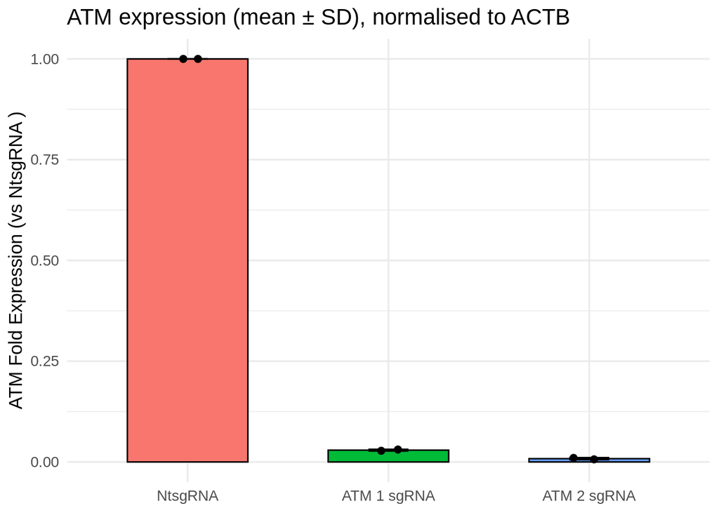

```r
# Bar (mean ± SD) with the 2 replicate points
ggplot(summary_df, aes(x = sample, y = mean_expr, fill = sample)) +
  geom_col(width = 0.6, colour = "black") +
  geom_errorbar(aes(ymin = mean_expr - sd_expr, ymax = mean_expr + sd_expr),
                width = 0.2) +
  geom_point(data = fc_all, aes(sample, fold_change),
             position = position_jitter(width = 0.08, height = 0), size = 2) +
  labs(
    y = paste(TARGET_GENE, "Fold Expression (vs", CONTROL_LABEL, ")"),
    x = NULL,
    title = paste(TARGET_GENE, "expression (mean ± SD), normalised to", REF_GENE)
  ) +
  theme_minimal(base_size = 13) +
  theme(legend.position = "none")
```

#### Figure 1. ATM expression after sgRNA transfection, quantified by qPCR. Bars show the mean fold expression of ATM (2^-ΔΔCt), where ΔCt values were normalised to the reference gene ACTB, and ΔΔCt values were calibrated to the non-targeting control (NtsgRNA), which is set to 1.0. Black dots indicate the two technical replicates (n = 2) both from the same sample, and error bars represent ± SD. Both ATM-targeting guides (ATM 1 sgRNA and ATM 2 sgRNA) show strong knockdown of ATM compared with the NtsgRNA control, with expression reduced to only a small fraction of control levels (low bars indicate greater knockdown).

#### qPCR results from (ii), comparing 0.45 µM vs 0.045 µM sgRNA input across 2 biological replicates of reverse transfections manually.

```r
## 1) Read your dataset (Excel)
library(readxl)

data <- read_excel("pcr_reverse_transfection_data.xlsx", sheet = 1)
head(data)
```

```
## # A tibble: 6 × 5
##   gene    concentration_uM primer Ct_Bio1 Ct_Bio2
##   <chr>              <dbl> <chr>    <dbl>   <dbl>
## 1 ATM 1              0.045 ACTB      16.4    18.6
## 2 ATM 1              0.045 ATM       31.6    32.6
## 3 ATM 2              0.045 ACTB      16.7    19.0
## 4 ATM 2              0.045 ATM       32.0    32.6
## 5 NtsgRNA            0.045 ACTB      16.0    17.4
## 6 NtsgRNA            0.045 ATM       25.4    26.7
```

```r
## 1) Labels
CONTROL_LABEL <- "NtsgRNA"  # control
TARGET_GENE   <- "ATM"      # target gene
REF_GENE      <- "ACTB"     # housekeeping gene

## 2) Robust column mapping

get_first_col <- function(df, options) {
  found <- intersect(names(df), options)
  if (length(found) == 0) stop("Missing expected column. Looked for: ",
                               paste(options, collapse=", "))
  found[1]
}

gene_col <- get_first_col(data, c("gene","Gene"))
primer_col <- get_first_col(data, c("primer","Primer"))
ct1_col <- get_first_col(data, c("Ct_Bio1","ct_bio1"))
ct2_col <- get_first_col(data, c("Ct_Bio2","ct_bio2"))
conc_col <- get_first_col(data, c("concentration_uM","concentration_um",
                                  "Concentration_uM","Concentration_um"))

df <- data %>%
  transmute(
    gene             = as.character(.data[[gene_col]]),
    concentration_uM = suppressWarnings(as.numeric(.data[[conc_col]])),
    primer           = toupper(str_trim(as.character(.data[[primer_col]]))),
    Ct_Bio1          = suppressWarnings(as.numeric(.data[[ct1_col]])),
    Ct_Bio2          = suppressWarnings(as.numeric(.data[[ct2_col]]))
  ) %>%
  mutate(
    gene = case_when(
      str_to_upper(gene) == "NTSGRNA" ~ "NtsgRNA",
      str_to_upper(gene) == "ATM 1"   ~ "ATM 1",
      str_to_upper(gene) == "ATM 2"   ~ "ATM 2",
      TRUE                            ~ gene
    )
  )

## 3) Display label for concentration
fmt_conc <- function(x) {
  s <- format(x, trim = TRUE, scientific = FALSE, digits = 12)
  s <- sub("0+$", "", s)   # drop trailing zeros
  s <- sub("\\.$", "", s)  # drop trailing dot if any
  s
}
df <- df %>% mutate(conc_label = fmt_conc(concentration_uM))

## 4) Show the INPUT Ct table per replicate
ct_input_table <- df %>%
  arrange(concentration_uM, gene, primer) %>%
  transmute(
    gene,
    concentration_uM = conc_label,   # formatted display only
    primer,
    Bio1 = round(Ct_Bio1, 3),
    Bio2 = round(Ct_Bio2, 3)
  )

if (requireNamespace("knitr", quietly = TRUE)) {
  knitr::kable(ct_input_table, caption = "Input Ct per replicate (Bio1, Bio2)")
} else {
  print(ct_input_table)
}
```

Input Ct per replicate (Bio1, Bio2)

| gene | concentration_uM | primer | Bio1 | Bio2 |
| --- | --- | --- | --- | --- |
| ATM 1 | 0.045 | ACTB | 16.428 | 18.642 |
| ATM 1 | 0.045 | ATM | 31.591 | 32.600 |
| ATM 2 | 0.045 | ACTB | 16.670 | 18.990 |
| ATM 2 | 0.045 | ATM | 31.988 | 32.618 |
| NtsgRNA | 0.045 | ACTB | 16.028 | 17.423 |
| NtsgRNA | 0.045 | ATM | 25.445 | 26.719 |
| ATM 1 | 0.45 | ACTB | 16.948 | 18.327 |
| ATM 1 | 0.45 | ATM | 30.522 | 33.205 |
| ATM 2 | 0.45 | ACTB | 16.523 | 19.205 |
| ATM 2 | 0.45 | ATM | 31.160 | 34.315 |
| NtsgRNA | 0.45 | ACTB | 17.024 | 16.934 |
| NtsgRNA | 0.45 | ATM | 26.323 | 26.255 |

```r
## 5) ΔCt PER REPLICATE: Ct(TARGET) - Ct(REF) for each Bio
ct_long <- df %>%
  pivot_longer(c(Ct_Bio1, Ct_Bio2),
               names_to = "bio", values_to = "ct") %>%
  mutate(bio = recode(bio, Ct_Bio1 = "Bio1", Ct_Bio2 = "Bio2")) %>%
  filter(primer %in% c(TARGET_GENE, REF_GENE), is.finite(ct))

dCt <- ct_long %>%
  select(bio, gene, concentration_uM, primer, ct) %>%
  # (group_by/summarise kept for safety—does nothing if already 1 row per combo)
  group_by(bio, gene, concentration_uM, primer) %>%
  summarise(ct = mean(ct, na.rm = TRUE), .groups = "drop") %>%
  tidyr::pivot_wider(names_from = primer, values_from = ct) %>%
  mutate(delta_ct = .data[[TARGET_GENE]] - .data[[REF_GENE]]) %>%
  select(bio, gene, concentration_uM, delta_ct)

## 6) ΔΔCt PER REPLICATE: calibrate to NtsgRNA at SAME conc.
cal <- dCt %>%
  filter(gene == CONTROL_LABEL) %>%
  select(bio, concentration_uM, cal_delta_ct = delta_ct)

ddCt <- dCt %>%
  left_join(cal, by = c("bio","concentration_uM")) %>%
  mutate(
    delta_delta_ct = delta_ct - cal_delta_ct,
    fold_change    = 2^(-delta_delta_ct)
  ) %>%
  arrange(concentration_uM, gene, bio)

## 7) TABLE A — PER-REPLICATE FOLD CHANGE (Bio1 & Bio2)
fc_per_bio <- ddCt %>%
  mutate(concentration = fmt_conc(concentration_uM)) %>%  # display-only label
  select(concentration, gene, bio, fold_change) %>%
  mutate(fold_change = round(fold_change, 4)) %>%
  tidyr::pivot_wider(names_from = bio, values_from = fold_change) %>%
  arrange(concentration, gene)

if (requireNamespace("knitr", quietly = TRUE)) {
  knitr::kable(fc_per_bio, caption = "Fold change (2^-ΔΔCt) per biological replicate")
} else {
  print(fc_per_bio)
}
```

Fold change (2^-ΔΔCt) per biological replicate

| concentration | gene | Bio1 | Bio2 |
| --- | --- | --- | --- |
| 0.045 | ATM 1 | 0.0186 | 0.0395 |
| 0.045 | ATM 2 | 0.0167 | 0.0497 |
| 0.045 | NtsgRNA | 1.0000 | 1.0000 |
| 0.45 | ATM 1 | 0.0517 | 0.0212 |
| 0.45 | ATM 2 | 0.0247 | 0.0181 |
| 0.45 | NtsgRNA | 1.0000 | 1.0000 |

```r
## 8) TABLE B — COMBINED Mean ± SD (across Bio1 & Bio2)
fc_summary <- ddCt %>%
  mutate(concentration = fmt_conc(concentration_uM)) %>%
  group_by(concentration, gene) %>%
  summarise(
    mean_fold_change = round(mean(fold_change, na.rm = TRUE), 4),
    sd_fold_change   = round(sd(fold_change,   na.rm = TRUE), 4),
    .groups = "drop"
  ) %>%
  arrange(concentration, gene)

if (requireNamespace("knitr", quietly = TRUE)) {
  knitr::kable(fc_summary, caption = "Mean ± SD fold change across biological replicates")
} else {
  print(fc_summary)
}
```

Mean ± SD fold change across biological replicates

| concentration | gene | mean_fold_change | sd_fold_change |
| --- | --- | --- | --- |
| 0.045 | ATM 1 | 0.0291 | 0.0148 |
| 0.045 | ATM 2 | 0.0332 | 0.0233 |
| 0.045 | NtsgRNA | 1.0000 | 0.0000 |
| 0.45 | ATM 1 | 0.0364 | 0.0215 |
| 0.45 | ATM 2 | 0.0214 | 0.0047 |
| 0.45 | NtsgRNA | 1.0000 | 0.0000 |

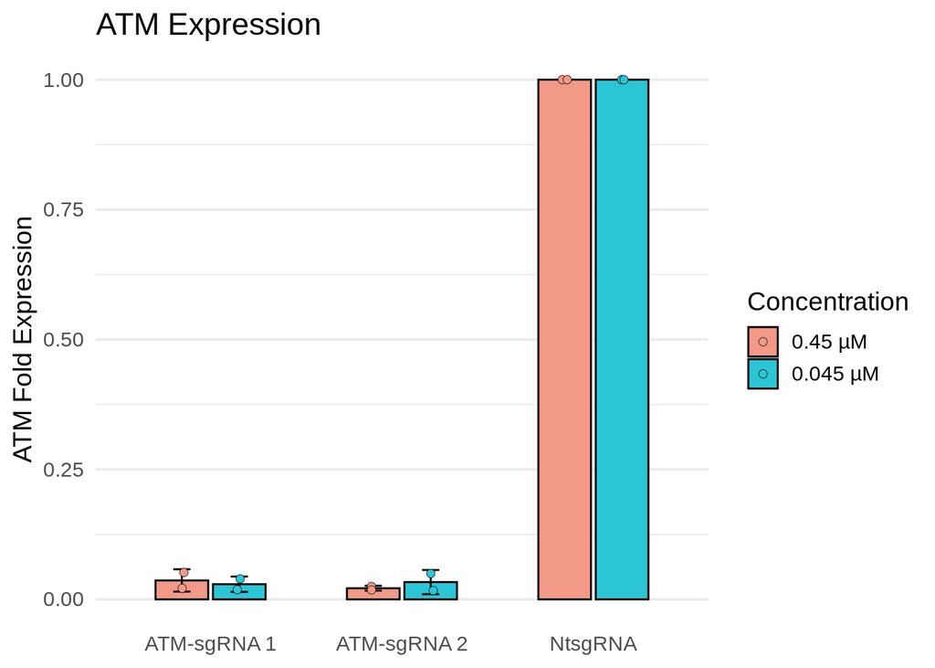

```r
## 9) Combined plot (two concentrations + SD + replicate points)
library(ggplot2)
library(forcats)

# Display labels for plot only (keep your calculations unchanged)
fc_plot <- fc_summary %>%
  mutate(
    gene_lbl = dplyr::recode(gene,
      "ATM 1" = "ATM-sgRNA 1",
      "ATM 2" = "ATM-sgRNA 2",
      "NtsgRNA" = "NtsgRNA"
    ),
    conc_lbl = factor(paste0(concentration, " \u00B5M"),
                      levels = c("0.45 \u00B5M", "0.045 \u00B5M"))
  )

dd_plot <- ddCt %>%
  mutate(
    gene_lbl = dplyr::recode(gene,
      "ATM 1" = "ATM-sgRNA 1",
      "ATM 2" = "ATM-sgRNA 2",
      "NtsgRNA" = "NtsgRNA"
    ),
    conc_lbl = factor(paste0(fmt_conc(concentration_uM), " \u00B5M"),
                      levels = c("0.45 \u00B5M", "0.045 \u00B5M"))
  )

# Colours to match your example (feel free to tweak)
cols <- c("0.45 \u00B5M" = "#F29988", "0.045 \u00B5M" = "#2CC5D5")

p <- ggplot(fc_plot, aes(x = gene_lbl, y = mean_fold_change, fill = conc_lbl)) +
  # bars (nearly overlapping via a tight dodge)
  geom_col(position = position_dodge(width = 0.6), width = 0.55, colour = "black") +
  # error bars (SD)
  geom_errorbar(aes(ymin = mean_fold_change - sd_fold_change,
                    ymax = mean_fold_change + sd_fold_change,
                    group = conc_lbl),
                position = position_dodge(width = 0.6), width = 0.18) +
  # overlay the two bio replicate points
  geom_point(data = dd_plot,
             aes(x = gene_lbl, y = fold_change, fill = conc_lbl),
             position = position_jitterdodge(jitter.width = 0.06, dodge.width = 0.6),
             size = 2, shape = 21, stroke = 0.2, colour = "black") +
  scale_fill_manual(values = cols, name = "Concentration") +
  labs(title = "ATM Expression",
       y = "ATM Fold Expression",
       x = NULL) +
  theme_minimal(base_size = 14) +
  theme(
    panel.grid.major.x = element_blank(),
    legend.position = "right"
  )

p
```

#### Figure 2. ATM expression across two sgRNA concentrations (mean ± SD). qPCR of ATM after reverse transfection with ATM-sgRNA 1 or ATM-sgRNA 2 at 0.45 µM or 0.045 µM, with NtsgRNA as the control. Ct values were first normalised to ACTB to give ΔCt = Ct(ATM) − Ct(ACTB). Then, for each concentration, we subtracted the control’s ΔCt (NtsgRNA) from each sample’s ΔCt—i.e., ΔΔCt = ΔCt(sample) − ΔCt(control at same conc). Fold expression was calculated as 2^-ΔΔCt, so the control is ~1.0. Bars show the mean of n = 2 biological replicates, error bars = SD, and open circles show individual replicate values. Both ATM-targeting guides strongly reduce ATM expression at both concentrations, with only modest guide and dose-dependent differences.